# Gender in Film

Amalin Sorajja

2023-09-21

```r
library(ggplot2)
library(dplyr)
library(readr)
library(pandoc)
library(tidyverse)
library(jsonlite)
# movies & credits datasets are from the same zip file, both with information on the same 45476 observations
movies <- read_csv("movies_metadata.csv") # includes stringified JSON objects in some columns
credits <- read.csv("credits.csv", stringsAsFactors = FALSE) # includes two columns which are stringified JSON objects (includes gender)
View(movies)
View(credits)
```

> This first code chunk is parsing data from the credits.csv column labeled “cast” and includes information about primary and secondary characters of the film including gender. Then, I merged with the movies dataset to get budget and revenue.

```r
parse_cast <- function(cast_text) {
  text <-
    sub("\\£\\$\\£", "",    #drop the first one
        gsub("\'|\"|\\[|\\]|\\{|\\}|,", "",
             gsub("\'cast_id\':|\'character\':|\'credit_id\':|\'gender\':|\'id\':|\'name\':|\'order\':|\'profile_path\':",
                  "£$£",
                  cast_text)
        )
    )

  data <- data.frame(matrix(
    trimws(unlist(
        strsplit(text, "\\£\\$\\£")
        )),
    ncol = 8, byrow = TRUE), stringsAsFactors = FALSE)

  names(data) <- c("cast_id", "character", "credit_id", "gender", "id", "name", "order", "profile_path")
  data$order <- as.numeric(data$order)

  return(data %>% select(cast_id, gender, id, name, order))
}

num_batches <- 50
batch_interval <- ceiling(nrow(credits) / num_batches)
batch_brackets <- 0:num_batches * batch_interval
batch_brackets[num_batches+1] <- nrow(credits)
batch_brackets[1] <- 1

cast_data <- data.frame()
for(b_i in 1:num_batches){

  batch_data <- data.frame()
  for(b2_i in batch_brackets[b_i]:(batch_brackets[b_i+1]-1)){
    #print(b2_i)
    this_cast <- parse_cast(credits$cast[b2_i])
    if(nrow(this_cast) > 0){
      this_cast$movie_id <- as.double(credits$id[b2_i])
      batch_data <- rbind(batch_data, this_cast)
    }
  }
  cast_data <- rbind(cast_data, batch_data)
  #print(paste0("    done batch ", b_i))
}

cast_data_plus <-
  left_join(cast_data,
            movies %>% select(id, title, genres, budget, revenue, vote_count, vote_average),
            by=c("movie_id" = "id"))
View(cast_data_plus)
```

> This second code chunk is parsing data from the credits.csv column labeled “crew” and includes information about production positions of the film including gender and department. Then, I merged with the movies dataset to get budget and revenue.

```r
parse_crew <- function(crew_text) {
  text <-
    sub("\\£\\$\\£", "",    #drop the first one
        gsub("\'|\"|\\[|\\]|\\{|\\}|,", "",
             gsub("\'credit_id\':|\'department\':|\'gender\':|\'id\':|\'job\':|\'name\':|\'profile_path\':",
                  "£$£",
                  crew_text)
        )
    )

  data <- data.frame(matrix(
    trimws(unlist(
        strsplit(text, "\\£\\$\\£")
        )),
    ncol = 7, byrow = TRUE), stringsAsFactors = FALSE)

  names(data) <- c("credit_id", "department", "gender", "id", "job", "name", "profile_path")

  return(data %>% select(credit_id, department, gender, id, job, name))
}

num_batches <- 50
batch_interval <- ceiling(nrow(credits) / num_batches)
batch_brackets <- 0:num_batches * batch_interval
batch_brackets[num_batches+1] <- nrow(credits)
batch_brackets[1] <- 1

crew_data <- data.frame()
for(b_i in 1:num_batches){

  batch_data <- data.frame()
  for(b2_i in batch_brackets[b_i]:(batch_brackets[b_i+1]-1)){
    #print(b2_i)
    this_crew <- parse_crew(credits$crew[b2_i])
    if(nrow(this_crew) > 0){
      this_crew$movie_id <- as.double(credits$id[b2_i])
      batch_data <- rbind(batch_data, this_crew)
    }
  }
  crew_data <- rbind(crew_data, batch_data)
  #print(paste0("    done batch ", b_i))
}

crew_data_plus <-
  left_join(crew_data,
            movies %>% select(id, genres, title, budget, revenue, vote_count, vote_average),
            by=c("movie_id" = "id"))
View(crew_data_plus)
```

> To answer some questions we have about gender representation in media, I found a dataset that contains information on >45000 movies released in or before July 2017. This information includes the movie title, cast, gender of each cast member (our most ideal variable - 0, 1, or 2 - “Unspecified”, “Female”, “Male”, respectively), movie budget, revenue, genre, and order of importance of each cast member (0-n if n is the number of cast members).

> For our project, one thing we have been wanting to investigate is if there are patterns of differences when our protagonist is female compared to when our protagonist is male. After parsing and cleaning my data, I wanted to observe just how much more budget male protagnist movies get than female protagonist movies. Thus, the question my visualization aims to answer is: How much budget does a movie get when the main character is male compared to female? This question is important for showing the inequality and perhaps the inequity in the film industry.

```r
cast_data_plus$gender[cast_data_plus$gender==0] <- "Unspecified"
cast_data_plus$gender[cast_data_plus$gender==1] <- "Female"
cast_data_plus$gender[cast_data_plus$gender==2] <- "Male"

maincharacters <- cast_data_plus %>%
  filter(order == 0) %>%
  filter(gender != "Unspecified")

mainchartop20budget <- maincharacters %>%
  group_by(gender) %>%
  arrange(desc(budget)) %>%
  slice(1:10) %>%
  mutate(title1 = as.factor(gsub("Pirates of the Caribbean","PotC", title))) %>%
  mutate(title2 = as.factor(gsub("Harry Potter and", "HP &", title1))) %>%
  mutate(title3 = as.factor(gsub("Part 1", "1", title2))) %>%
  mutate(title4 = as.factor(gsub(": A Star Wars Story", "", title3))) %>%
  mutate(title5 = as.factor(gsub("Star Wars:", "", title4))) %>%
  mutate(newbudget = budget/1000000)
```

> To answer this question, I selected information on only the main character of each movie (order = 0). Then grouped by gender and took the top 10 highest budgeted movies of each gender.

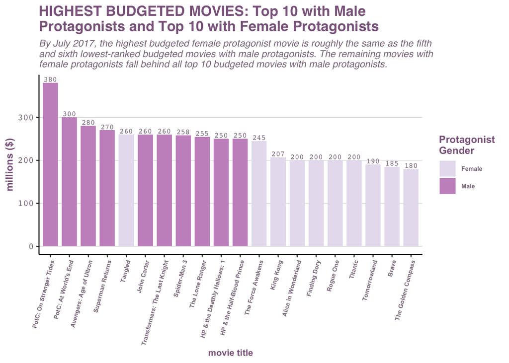

```r
mainchartop20budget %>%
  ggplot(aes(x = fct_reorder(title5, desc(newbudget)), y = newbudget, fill = gender)) +
  geom_col(width = 0.8) +
  geom_text(aes(label = newbudget, vjust = -0.3), size = 2.6, family = "mono", color = "thistle4") +
  xlab("movie title") +
  ylab("millions ($)") +
  labs(title = "HIGHEST BUDGETED MOVIES: Top 10 with Male \nProtagonists and Top 10 with Female Protagonists", fill = "Protagonist \nGender", subtitle = "By July 2017, the highest budgeted female protagonist movie is roughly the same as the fifth \nand sixth lowest-ranked budgeted movies with male protagonists. The remaining movies with \nfemale protagonists fall behind all top 10 budgeted movies with male protagonists.") +
  theme_classic() +
  theme(panel.grid.major.x = element_blank() ,
        panel.grid.major.y = element_line(size=.1, color="darkgrey"),
        axis.text.x = element_text(angle = 75, size = 6, hjust = 1, color = "thistle4", face = "bold"),
        axis.text.y = element_text(family = "mono", color = "thistle4", size = 9),
        axis.title.y = element_text(size = 10, face = "bold", color = "plum4"),
        plot.title = element_text(family = "sans",size = 14, face = "bold", colour = "plum4"),
        axis.title.x = element_text(size = 9, face ="bold", color = "plum4"),
        plot.subtitle = element_text(family = "sans",size = 9.5, face = "italic", color = "thistle4"),
        legend.title = element_text(size = 10, face = "bold", color = "plum4"),
        legend.text = element_text(size = 6, face = "bold", color = "thistle4")) +
  scale_fill_brewer(palette = "PuRd")
```

> To compare the movie budgets, I graphed the top 10 highest budget movies for each gender in descending order on a column plot, where the darker colored columns are male protagonist movies and the lighter colored columns are female protagonist movies, with the movie titles along the x-axis. I decided to divide budget by one million for visualization purposes.

> Interestingly so, the highest budgeted movie with a female protagonist has roughly the same budget as the fifth and sixth lowest-ranked budgeted movies with male protagonists, falling 120 million behind the highest budgeted movie with a male protagonist. The remaining 9 female protagonist movies fall behind all 10 highest male budgeted movies.

> Another takeaway is that the highest budgeted movie with a female protagonist “Tangled” is an animated film, and the voice actor, may not actually be getting as much as Johnny Depp in Pirates of the Caribbean. So that budgeted money may actually be going more towards production, rather than the female actress. In total, there are three animated movies in the top 10 highest budgeted movies with female protagonists, whereas there are none in the top 10 for male protagonists. Therefore it may be that there is more investment in movies that are animated due to production, and those animated films happen to have female protagonists. So my question is do they not want to invest as much if there is a real, live action female protagonist?

> It would be nice to have a variable of how much the actors are getting and comparing that as well (voice actors are paid a lot less I believe).